# Point Process Homework (Basics)

Instructions: Answer the following questions and write your answers in a word processor. Mathematical symbols should be written using the equation editor. Appropriate graphics should be included. The document may also be created in LaTeX, though this is NOT encouraged.

# Problem 1

What are the two components needed to define a spatial point process?

An event and a space within event study.

# Problem 2

What are the main components that define a homogeneous Poisson point process?

A poisson point process is defined by poisson distribution N ~ Poisson(lambda(|A|)). Where lambda is the intensity across the whole area which is set as A thus a sensible estimator for lambda might be N(number of events)/|A|

# Problem 3

What is the main difference between a homogeneous and heterogeneous Poisson point process?

The homogeneous is set out as a constant whereas we have heterogeneous poisson point process that allows for varying levels of intensity across the study space where each event has a different intensity compared to homogenous.

# Problem 4

Describe the differences between a regular, clustered, and homogeneous (CSR) Poisson point process?

Before anything it all matters on scale of the study. Also you can have regular clustered events and clustered regular events. The CSR process has the same value of intensity and is spread out where there is true complete spacial randomness so you are not expecting any sort of patterns. Regular is more everything falls equidistant from each other so if I am wearing a poka dot shirt. Clustered would be more like a group of kids at lunch where they bunch up into several different groups we see a pattern where they are more closely related to isotropic.

# Problem 5

Draw pictures depicting a realization of a regular, clustered, and homogeneous (CSR) Poisson point process?

[figure not shown]

# Problem 6

Run the following command in R to simulate a homogeneous Poisson point process with intensity `lambda = 50` over the domain $[0, 1]\times[0,1]$.

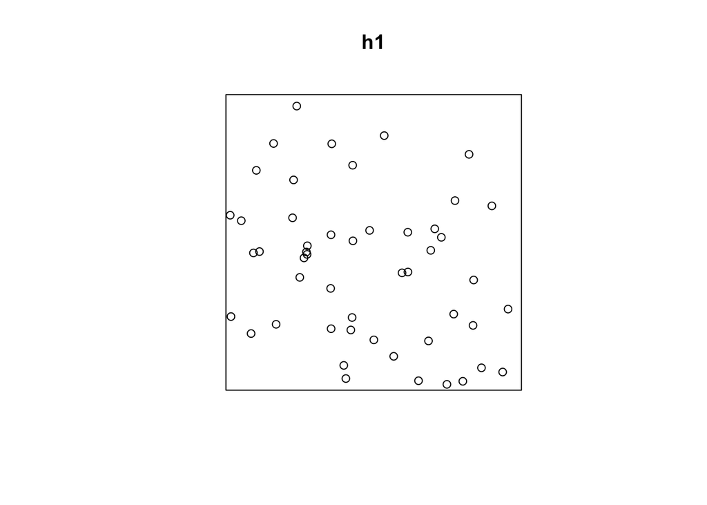

```r
library(spatstat)
set.seed(10)
h1 <- rpoispp(50)
plot(h1)
```

```r
npoints(h1)
```

```
[1] 50
```

Plot `h1` and comment on what you observe. How many points were generated? Do the event location seem to be compatible with CSR?

I got 50 points, they seem to be compariable with CSR somewhat, however, some of them look more regular than others due to the spacing in the top right but also clustered if we look at the very bottom but more than anything they do look like they are affected under CSR.

# Problem 7

Let’s create our own function to simulate data that are compatible with complete spatial randomness over a $[0, 1]\times[0,1]$ study area.

Create a function named `rcsr` that takes the parameter `lambda`.

The function should do three things:

1. Simulate `N`, the number of event locations, from a Poisson distribution with mean equal to `lambda`.
2. For the selected value of `N`, draw `N` events uniformly over the domain $[0, 1]\times[0,1]$.
   1. Draw the x-coordinate uniformly between [0, 1].
   2. Draw the y-coordinate uniformly between [0, 1].
3. Convert the `N` event locations to a `ppp` object.
4. Return the `ppp` object.

Run the function one time using $lambda = 50$ and plot the results.

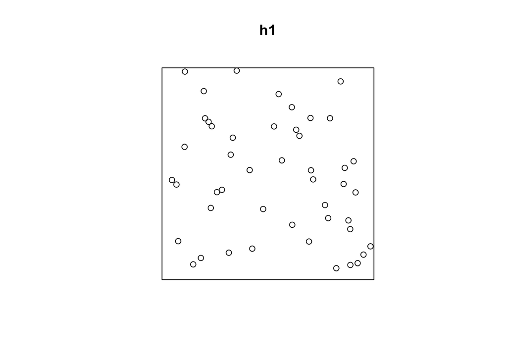

```
Planar point pattern: 47 points
window: rectangle = [0, 1] x [0, 1] units
```

```r
rcsr <- function(lambda) {
  h1 <- rpoispp(lambda, win = owin(c(0, 1), c(0, 1)))
  N <- npoints(h1)
  ppp <- ppp(h1[["x"]],h1[["y"]], win = owin(c(0, 1), c(0, 1)))
  plot(h1)
  return(ppp)
}
rcsr(50)
```

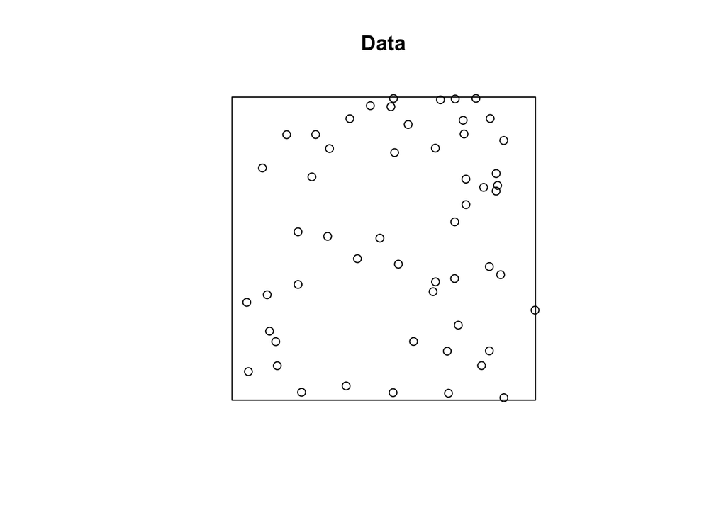

```r
rcsr <- function(lambda){
N <- rpois(1,lambda = lambda)
xrand <- runif(N,min=0,max=1)
yrand <- runif(N,min=0,max=1)
pprec <-  ppp(x = xrand, y = yrand,
            window = owin(c(0, 1), c(0, 1)))
}

Data <- rcsr(50)
plot(Data)
```